# 24133064_NguyenThiKieuTrang_Lab2_VISDATA

2026-05-13

```r
library(tidyverse)
```

# Phần 1. Với dữ liệu recent_grads

```r
recent_grads <-read.csv("recent_grads.csv")
```

## Q1.

## Khám phá cấu trúc dữ liệu recent_grads: xem số dòng, số cột, tên biến, kiểu dữ liệu, vài dòng đầu và thống kê mô tả của các biến chính

### Xem số và số cột

```r
dim(recent_grads)
```

```
## [1] 173  21
```

### Xem tên biến

```r
names(recent_grads)
```

```
##  [1] "Rank"                 "Major_code"           "Major"
##  [4] "Total"                "Men"                  "Women"
##  [7] "Major_category"       "ShareWomen"           "Sample_size"
## [10] "Employed"             "Full_time"            "Part_time"
## [13] "Full_time_year_round" "Unemployed"           "Unemployment_rate"
## [16] "Median"               "P25th"                "P75th"
## [19] "College_jobs"         "Non_college_jobs"     "Low_wage_jobs"
```

### Xem kiểu dữ liệu và cấu trúc

```r
str(recent_grads)
```

```
## 'data.frame':    173 obs. of  21 variables:
##  $ Rank                : int  1 2 3 4 5 6 7 8 9 10 ...
##  $ Major_code          : int  2419 2416 2415 2417 2405 2418 6202 5001 2414 2408 ...
##  $ Major               : chr  "PETROLEUM ENGINEERING" "MINING AND MINERAL ENGINEERING" "METALLURGICAL ENGINEERING" "NAVAL ARCHITECTURE AND MARINE ENGINEERING" ...
##  $ Total               : int  2339 756 856 1258 32260 2573 3777 1792 91227 81527 ...
##  $ Men                 : int  2057 679 725 1123 21239 2200 2110 832 80320 65511 ...
##  $ Women               : int  282 77 131 135 11021 373 1667 960 10907 16016 ...
##  $ Major_category      : chr  "Engineering" "Engineering" "Engineering" "Engineering" ...
##  $ ShareWomen          : num  0.121 0.102 0.153 0.107 0.342 ...
##  $ Sample_size         : int  36 7 3 16 289 17 51 10 1029 631 ...
##  $ Employed            : int  1976 640 648 758 25694 1857 2912 1526 76442 61928 ...
##  $ Full_time           : int  1849 556 558 1069 23170 2038 2924 1085 71298 55450 ...
##  $ Part_time           : int  270 170 133 150 5180 264 296 553 13101 12695 ...
##  $ Full_time_year_round: int  1207 388 340 692 16697 1449 2482 827 54639 41413 ...
##  $ Unemployed          : int  37 85 16 40 1672 400 308 33 4650 3895 ...
##  $ Unemployment_rate   : num  0.0184 0.1172 0.0241 0.0501 0.0611 ...
##  $ Median              : int  110000 75000 73000 70000 65000 65000 62000 62000 60000 60000 ...
##  $ P25th               : int  95000 55000 50000 43000 50000 50000 53000 31500 48000 45000 ...
##  $ P75th               : int  125000 90000 105000 80000 75000 102000 72000 109000 70000 72000 ...
##  $ College_jobs        : int  1534 350 456 529 18314 1142 1768 972 52844 45829 ...
##  $ Non_college_jobs    : int  364 257 176 102 4440 657 314 500 16384 10874 ...
##  $ Low_wage_jobs       : int  193 50 0 0 972 244 259 220 3253 3170 ...
```

### Xem vài dòng đầu

```r
head(recent_grads, 10)
```

```
##    Rank Major_code                                     Major Total   Men Women
## 1     1       2419                     PETROLEUM ENGINEERING  2339  2057   282
## 2     2       2416            MINING AND MINERAL ENGINEERING   756   679    77
## 3     3       2415                 METALLURGICAL ENGINEERING   856   725   131
## 4     4       2417 NAVAL ARCHITECTURE AND MARINE ENGINEERING  1258  1123   135
## 5     5       2405                      CHEMICAL ENGINEERING 32260 21239 11021
## 6     6       2418                       NUCLEAR ENGINEERING  2573  2200   373
## 7     7       6202                         ACTUARIAL SCIENCE  3777  2110  1667
## 8     8       5001                ASTRONOMY AND ASTROPHYSICS  1792   832   960
## 9     9       2414                    MECHANICAL ENGINEERING 91227 80320 10907
## 10   10       2408                    ELECTRICAL ENGINEERING 81527 65511 16016
##       Major_category ShareWomen Sample_size Employed Full_time Part_time
## 1        Engineering  0.1205643          36     1976      1849       270
## 2        Engineering  0.1018519           7      640       556       170
## 3        Engineering  0.1530374           3      648       558       133
```

[output cut: 29 more lines]

### Thống kê mô tả cơ bản

```r
summary(recent_grads)
```

```
##       Rank       Major_code         Major         Total             Men
##  Min.   :  1   Min.   :1100   Length   :173   Min.   :   124   Min.   :   119
##  1st Qu.: 44   1st Qu.:2403   N.unique :173   1st Qu.:  4550   1st Qu.:  2178
##  Median : 87   Median :3608   N.blank  :  0   Median : 15104   Median :  5434
##  Mean   : 87   Mean   :3880   Min.nchar:  5   Mean   : 39370   Mean   : 16723
##  3rd Qu.:130   3rd Qu.:5503   Max.nchar: 65   3rd Qu.: 38910   3rd Qu.: 14631
##  Max.   :173   Max.   :6403                   Max.   :393735   Max.   :173809
##                                               NAs    :1        NAs    :1
##      Women          Major_category   ShareWomen      Sample_size
##  Min.   :     0   Length   :173    Min.   :0.0000   Min.   :   2.0
##  1st Qu.:  1778   N.unique : 16    1st Qu.:0.3360   1st Qu.:  39.0
##  Median :  8386   N.blank  :  0    Median :0.5340   Median : 130.0
##  Mean   : 22647   Min.nchar:  4    Mean   :0.5222   Mean   : 356.1
##  3rd Qu.: 22554   Max.nchar: 35    3rd Qu.:0.7033   3rd Qu.: 338.0
##  Max.   :307087                    Max.   :0.9690   Max.   :4212.0
##  NAs    :1                         NAs    :1
##     Employed        Full_time        Part_time      Full_time_year_round
##  Min.   :     0   Min.   :   111   Min.   :     0   Min.   :   111
##  1st Qu.:  3608   1st Qu.:  3154   1st Qu.:  1030   1st Qu.:  2453
##  Median : 11797   Median : 10048   Median :  3299   Median :  7413
##  Mean   : 31193   Mean   : 26029   Mean   :  8832   Mean   : 19694
##  3rd Qu.: 31433   3rd Qu.: 25147   3rd Qu.:  9948   3rd Qu.: 16891
##  Max.   :307933   Max.   :251540   Max.   :115172   Max.   :199897
##
##    Unemployed    Unemployment_rate     Median           P25th
##  Min.   :    0   Min.   :0.00000   Min.   : 22000   Min.   :18500
##  1st Qu.:  304   1st Qu.:0.05031   1st Qu.: 33000   1st Qu.:24000
##  Median :  893   Median :0.06796   Median : 36000   Median :27000
##  Mean   : 2416   Mean   :0.06819   Mean   : 40151   Mean   :29501
##  3rd Qu.: 2393   3rd Qu.:0.08756   3rd Qu.: 45000   3rd Qu.:33000
##  Max.   :28169   Max.   :0.17723   Max.   :110000   Max.   :95000
##
##      P75th         College_jobs    Non_college_jobs Low_wage_jobs
##  Min.   : 22000   Min.   :     0   Min.   :     0   Min.   :    0
##  1st Qu.: 42000   1st Qu.:  1675   1st Qu.:  1591   1st Qu.:  340
##  Median : 47000   Median :  4390   Median :  4595   Median : 1231
##  Mean   : 51494   Mean   : 12323   Mean   : 13284   Mean   : 3859
##  3rd Qu.: 60000   3rd Qu.: 14444   3rd Qu.: 11783   3rd Qu.: 3466
##  Max.   :125000   Max.   :151643   Max.   :148395   Max.   :48207
##
```

### Biến phân loại

```r
recent_grads %>%
  select(Major, Major_category) %>%
  head()
```

```
##                                       Major Major_category
## 1                     PETROLEUM ENGINEERING    Engineering
## 2            MINING AND MINERAL ENGINEERING    Engineering
## 3                 METALLURGICAL ENGINEERING    Engineering
## 4 NAVAL ARCHITECTURE AND MARINE ENGINEERING    Engineering
## 5                      CHEMICAL ENGINEERING    Engineering
## 6                       NUCLEAR ENGINEERING    Engineering
```

### Biến định lượng

```r
recent_grads %>%
  select(Total, Median, Unemployment_rate, ShareWomen) %>%
  summary()
```

```
##      Total            Median       Unemployment_rate   ShareWomen
##  Min.   :   124   Min.   : 22000   Min.   :0.00000   Min.   :0.0000
##  1st Qu.:  4550   1st Qu.: 33000   1st Qu.:0.05031   1st Qu.:0.3360
##  Median : 15104   Median : 36000   Median :0.06796   Median :0.5340
##  Mean   : 39370   Mean   : 40151   Mean   :0.06819   Mean   :0.5222
##  3rd Qu.: 38910   3rd Qu.: 45000   3rd Qu.:0.08756   3rd Qu.:0.7033
##  Max.   :393735   Max.   :110000   Max.   :0.17723   Max.   :0.9690
##  NAs    :1                                           NAs    :1
```

## Bảng/tóm tắt dữ liệu và nhận xét ngắn về biến định lượng, biến phân loại.

### Bảng tóm tắt dữ liệu

```r
recent_grads %>%
  select(Major, Major_category,
         Total, Median,
         Unemployment_rate,
         ShareWomen) %>%
  summary()
```

```
##        Major       Major_category     Total            Median
##  Length   :173   Length   :173    Min.   :   124   Min.   : 22000
##  N.unique :173   N.unique : 16    1st Qu.:  4550   1st Qu.: 33000
##  N.blank  :  0   N.blank  :  0    Median : 15104   Median : 36000
##  Min.nchar:  5   Min.nchar:  4    Mean   : 39370   Mean   : 40151
##  Max.nchar: 65   Max.nchar: 35    3rd Qu.: 38910   3rd Qu.: 45000
##                                   Max.   :393735   Max.   :110000
##                                   NAs    :1
##  Unemployment_rate   ShareWomen
##  Min.   :0.00000   Min.   :0.0000
##  1st Qu.:0.05031   1st Qu.:0.3360
##  Median :0.06796   Median :0.5340
##  Mean   :0.06819   Mean   :0.5222
##  3rd Qu.:0.08756   3rd Qu.:0.7033
##  Max.   :0.17723   Max.   :0.9690
##                    NAs    :1
```

*Nhận xét*

Biến phân loại

- Major và Major_category là các biến phân loại.
- Major biểu diễn tên ngành học cụ thể.
- Major_category biểu diễn nhóm ngành lớn như Engineering, Business, Biology,…
- Các biến này dùng để phân nhóm và so sánh dữ liệu giữa các ngành.

Biến định lượng

- Total: tổng số sinh viên của ngành.
- Median: thu nhập trung vị sau tốt nghiệp.
- Unemployment_rate: tỷ lệ thất nghiệp.
- ShareWomen: tỷ lệ nữ trong ngành.

## Q2

## Vẽ biểu đồ histogram của thu nhập trung vị Median. Mỗi cột thể hiện số lượng ngành nằm trong một khoảng thu nhập

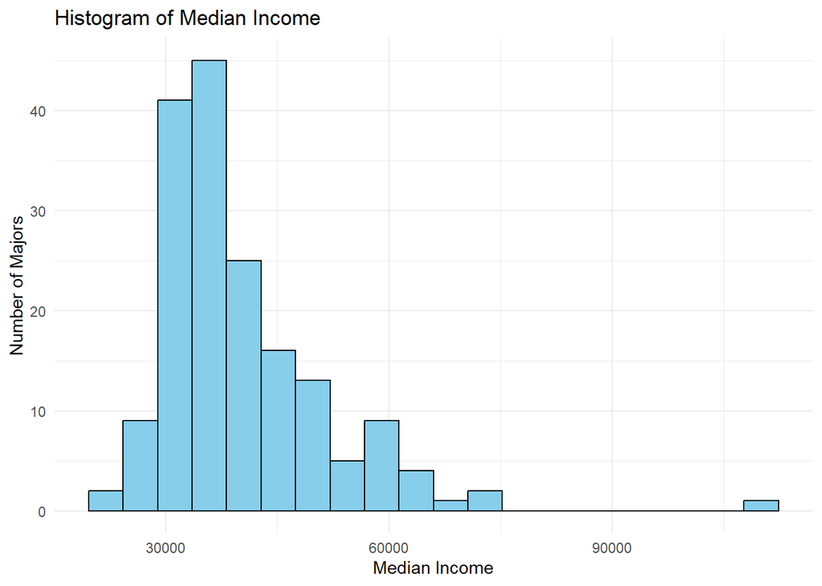

```r
ggplot(recent_grads, aes(x = Median)) +
  geom_histogram(
    bins = 20,
    fill = "skyblue",
    color = "black"
  ) +
  labs(
    title = "Histogram of Median Income",
    x = "Median Income",
    y = "Number of Majors"
  ) +
  theme_minimal()
```

## Giải thích trục x lấy từ Median và trục y là số lượng ngành được ggplot2 tự đếm

- Trục x lấy từ biến Median, thể hiện mức thu nhập trung vị của các ngành học.
- Trục y là số lượng ngành học trong mỗi khoảng thu nhập và được ggplot2 tự động đếm thông qua geom_histogram().
- Mỗi cột biểu diễn số ngành có mức thu nhập nằm trong khoảng tương ứng.

## Q3

## Thử thay đổi độ rộng khoảng của histogram và so sánh sự khác biệt.

### Histogram với binwidth nhỏ

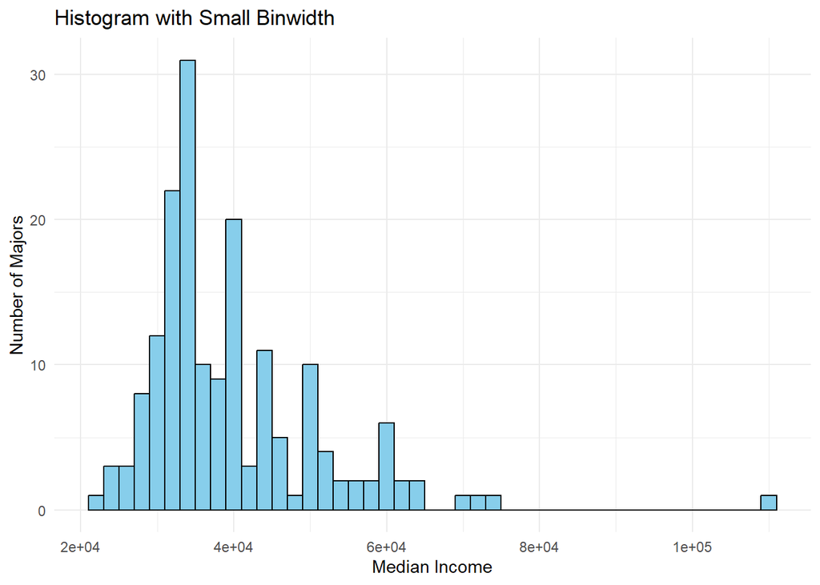

```r
ggplot(recent_grads, aes(x = Median)) +
  geom_histogram(
    binwidth = 2000,
    fill = "skyblue",
    color = "black"
  ) +
  labs(
    title = "Histogram with Small Binwidth",
    x = "Median Income",
    y = "Number of Majors"
  ) +
  theme_minimal()
```

### Histogram với binwidth lớn

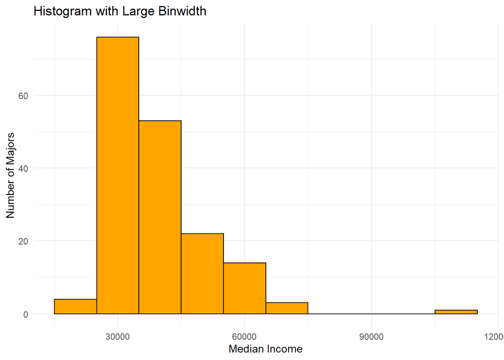

```r
ggplot(recent_grads, aes(x = Median)) +
  geom_histogram(
    binwidth = 10000,
    fill = "orange",
    color = "black"
  ) +
  labs(
    title = "Histogram with Large Binwidth",
    x = "Median Income",
    y = "Number of Majors"
  ) +
  theme_minimal()
```

*Nhận xét*

- Khi binwidth nhỏ, histogram có nhiều cột hơn và thể hiện chi tiết phân phối dữ liệu rõ hơn.
- Khi binwidth lớn, số cột giảm và biểu đồ nhìn tổng quát hơn nhưng mất bớt chi tiết.
- Việc thay đổi binwidth ảnh hưởng trực tiếp đến cách quan sát hình dạng phân phối của dữ liệu.

## Q4

### Biểu đồ bar chart top 10 ngành

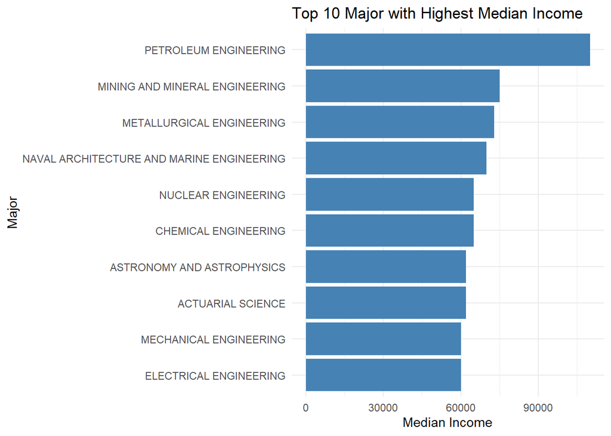

```r
top10_major <- recent_grads %>%
  arrange(desc(Median)) %>%
  slice(1:10)

ggplot(top10_major, aes(x=reorder(Major, Median), y=Median))+
  geom_col(fill="steelblue")+
  coord_flip()+
  labs(
    title="Top 10 Major with Highest Median Income",
    x="Major",
    y="Median Income"
  )+
  theme_minimal()
```

*Nhận xét ngành/nhóm ngành nào nổi bật*

- Ngành PETROLEUM ENGINEERING có thu nhập trung vị cao nhất,vượt trội so với các ngành còn lại.
- Phần lớn các ngành trong top 10 thuộc nhóm Engineering như:
- Mechanical Engineering
- Electrical Engineering
- Chemical Engineering
- Nuclear Engineering
- Ngoài nhóm kỹ thuật, ACTUARIAL SCIENCE và ASTRONOMY AND ASTROPHYSICS cũng có mức thu nhập cao.
- Điều này cho thấy các ngành kỹ thuật và khoa học chuyên môn cao thường có mức lương sau tốt nghiệp nổi bật hơn các nhóm ngành khác.

## Q5

### Vẽ scatter plot để phân tích mối quan hệ giữa tỷ lệ thất nghiệp và thu nhập trung vị.

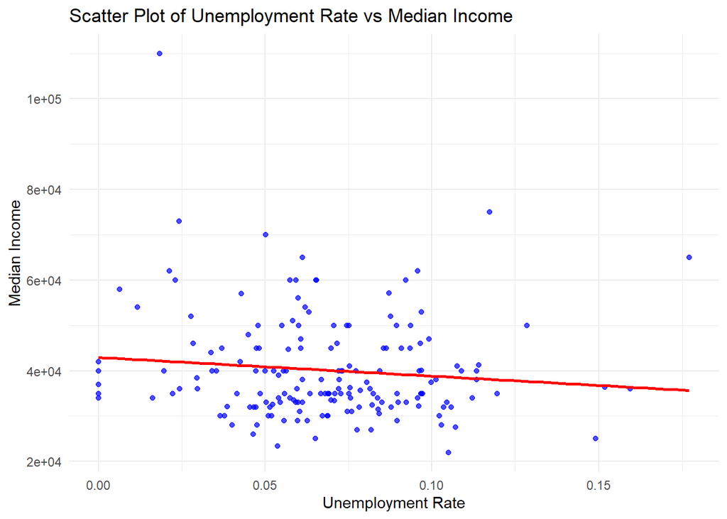

```r
ggplot(data=recent_grads, aes(x=Unemployment_rate, y=Median))+
  geom_point(color = "blue", alpha = 0.7) +
  geom_smooth(method = "lm",
              se = FALSE,
              color = "red") +
  labs(
    title = "Scatter Plot of Unemployment Rate vs Median Income",
    x = "Unemployment Rate",
    y = "Median Income"
  ) +
  theme_minimal()
```

## Q5

### So sánh phân phối thu nhập trung vị giữa các nhóm ngành bằng boxplot.

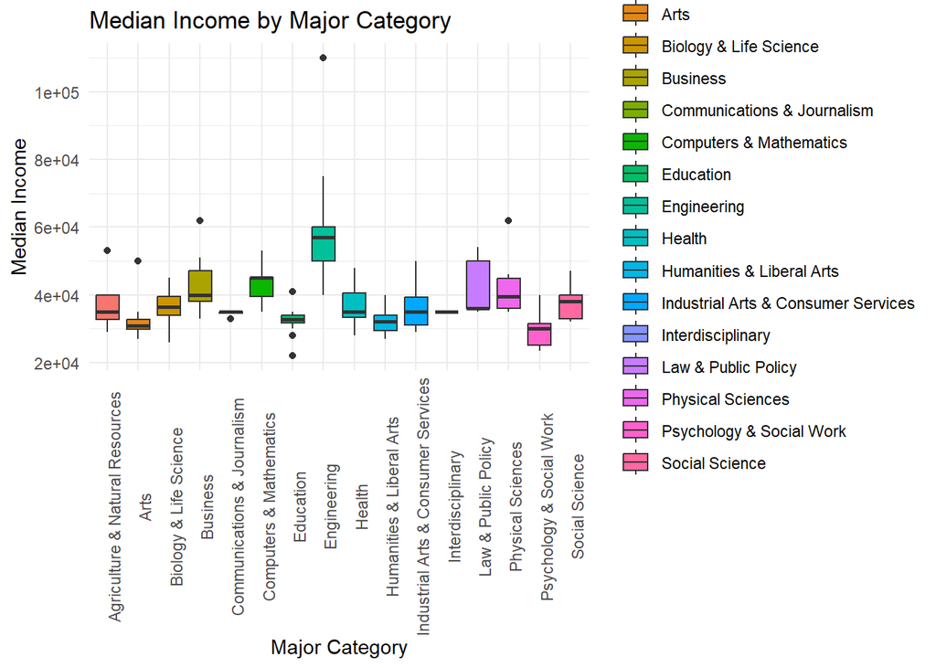

```r
ggplot(recent_grads, aes(x=Major_category,y=Median,fill=Major_category))+
  geom_boxplot()+
  labs(
    title="Median Income by Major Category",
    x="Major Category",
    y="Median Income"
  )+
  theme_minimal()+
  theme(
    axis.text.x=element_text(angle=90)
  )
```

*Nhận xét*

- Boxplot cho thấy nhóm Engineering có thu nhập trung vị (median) cao hơn phần lớn các nhóm ngành khác.
- Các nhóm như Arts, Education và Humanities & Liberal Arts có median thấp hơn.
- Nhóm Engineering và Physical Sciences có độ phân tán lớn hơn, thể hiện qua hộp và râu boxplot dài hơn, cho thấy thu nhập giữa các ngành trong nhóm chênh lệch đáng kể.
- Một số điểm ngoại lệ xuất hiện với mức thu nhập rất cao, nổi bật hơn phần lớn dữ liệu còn lại.
- Biểu đồ giúp so sánh đồng thời mức thu nhập trung vị và sự phân bố thu nhập giữa các nhóm ngành.

## Q6

### Biểu đồ facet

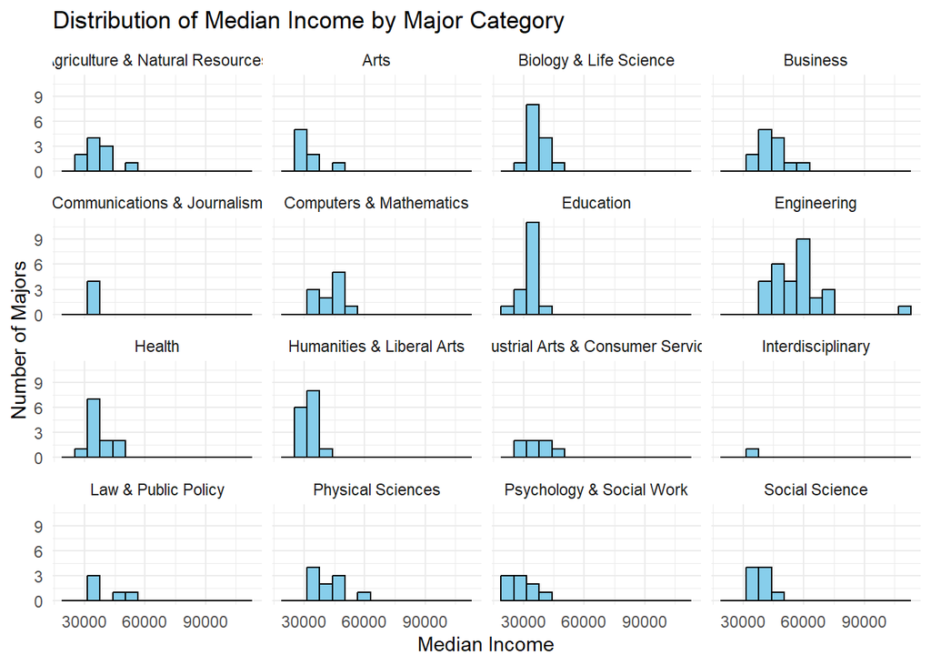

```r
ggplot(recent_grads,
       aes(x = Median)) +
  geom_histogram(
    bins = 15,
    fill = "skyblue",
    color = "black"
  ) +
  facet_wrap(~Major_category) +
  labs(
    title = "Distribution of Median Income by Major Category",
    x = "Median Income",
    y = "Number of Majors"
  ) +
  theme_minimal()
```

*Nhận xét*

- Biểu đồ facet cho thấy phân phối thu nhập trung vị khác nhau rõ rệt giữa các nhóm ngành.
- Nhóm Engineering và Computers & Mathematics có phân phối tập trung ở mức thu nhập cao hơn so với nhiều nhóm ngành khác.
- Các nhóm như Arts, Education và Humanities & Liberal Arts chủ yếu tập trung ở mức thu nhập thấp đến trung bình.
- Một số nhóm ngành có phân phối trải rộng hơn, cho thấy mức thu nhập giữa các ngành trong nhóm có sự chênh lệch đáng kể.
- Nhóm Engineering xuất hiện một vài ngành có thu nhập rất cao, tạo ra phần đuôi phân phối kéo dài về phía bên phải.
- Nhìn chung, các nhóm ngành kỹ thuật và khoa học có xu hướng thu nhập cao hơn các nhóm ngành xã hội và nghệ thuật.

## Q8

### Tạo một biểu đồ tự chọn có sử dụng ít nhất hai aesthetics ngoài x/y

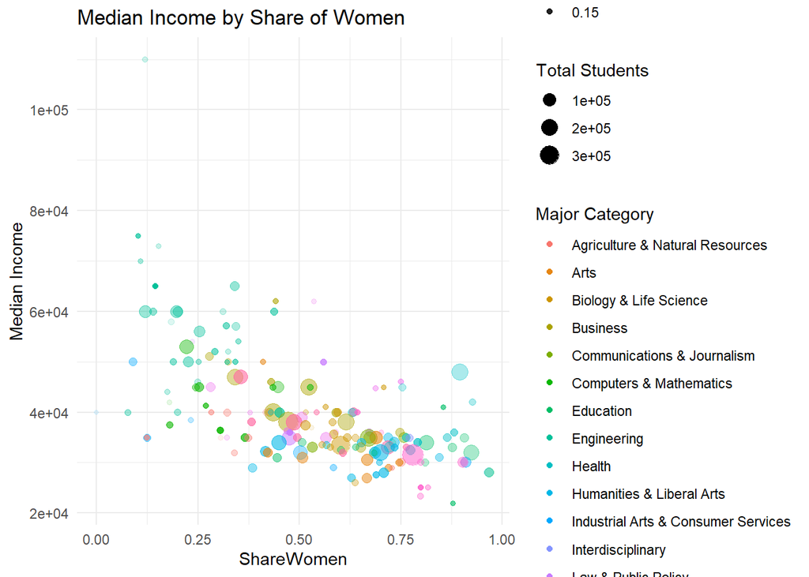

```r
ggplot(recent_grads,
       aes(x = ShareWomen,
           y = Median,
           color = Major_category,
           size = Total,
           alpha = Unemployment_rate)) +
  geom_point() +
  labs(
    title = "Median Income by Share of Women",
    x = "ShareWomen",
    y = "Median Income",
    color = "Major Category",
    size = "Total Students",
    alpha = "Unemployment Rate"
  ) +
  theme_minimal()
```

### Giải thích: biến nào được map vào color/size/alpha, thuộc tính nào là giá trị cố định.

color = Major_category → màu sắc được map theo nhóm ngành để phân biệt các ngành khác nhau.

size = Total → kích thước điểm được map theo tổng số sinh viên của ngành.

Ngành có nhiều sinh viên hơn sẽ có điểm lớn hơn. alpha = Unemployment_rate → độ trong suốt của điểm được map theo tỷ lệ thất nghiệp.

### Thuộc tính là giá trị cố định

- geom_point() được dùng cố định để tạo scatter plot.
- theme_minimal() là giao diện cố định của biểu đồ.
- Không đặt màu cố định vì màu đã được map theo biến Major_category.

# Phần 2: Với dữ liệu company_sales

```r
company_sales <-read.csv("company_sales_data.csv")
```

## Q1

### Biểu đồ đường thể hiện sự thay đổi của total_profit theo month_number.

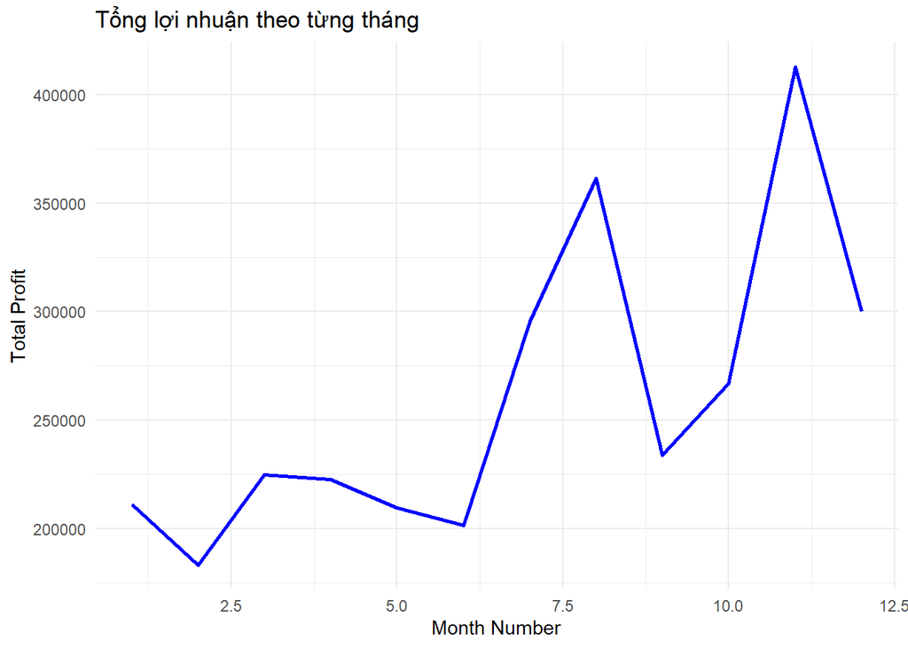

```r
ggplot(company_sales, aes(x=month_number, y=total_profit))+
  geom_line(color = "blue", linewidth = 1)+
  labs(
    title = "Tổng lợi nhuận theo từng tháng",
    x = "Month Number",
    y = "Total Profit")+
  theme_minimal()
```

## Q2

### Vẽ biểu đồ đường thể hiện tổng số sản phẩm bán ra theo tháng

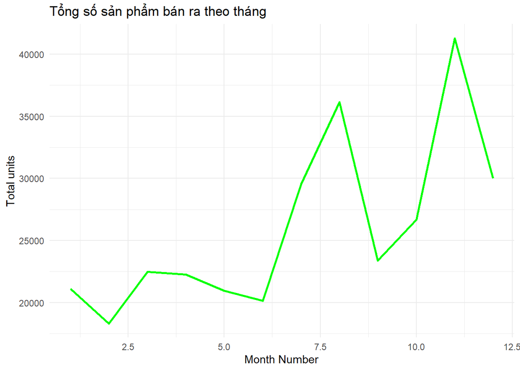

```r
ggplot(company_sales, aes(x=month_number, y=total_units))+
  geom_line(color="green", linewidth = 1)+
  labs(
    title="Tổng số sản phẩm bán ra theo tháng",
     x = "Month Number",
     y = "Total units")+
  theme_minimal()
```

*Phân tích*

- Doanh số bán hàng thay đổi qua các tháng trong năm.
- Tháng 2 có doanh số thấp nhất, khoảng 18.000 sản phẩm.
- Tháng 11 có doanh số cao nhất, hơn 41.000 sản phẩm.
- Đầu năm doanh số khá thấp và biến động nhẹ.Giữa năm bắt đầu tăng mạnh.
- Doanh số tăng mạnh vào giai đoạn cuối năm, đặc biệt từ tháng 10 đến tháng 11.

## Q3

### So sánh doanh số bán của facecream và facewash theo tháng.

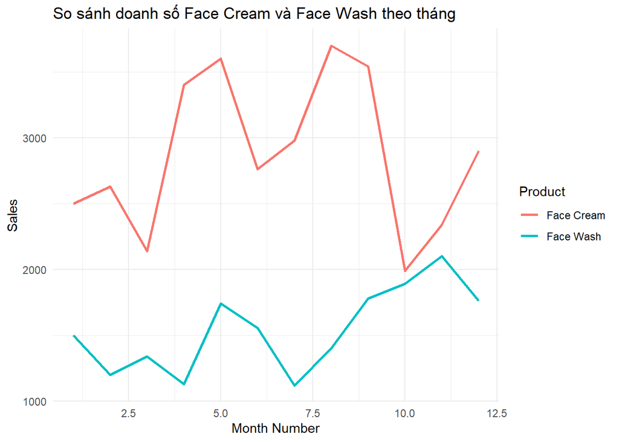

```r
ggplot(company_sales, aes(x = month_number)) +
  geom_line(aes(y = facecream, color = "Face Cream"),
            linewidth = 1) +
  geom_line(aes(y = facewash, color = "Face Wash"),
            linewidth = 1) +
  labs(
    title = "So sánh doanh số Face Cream và Face Wash theo tháng",
    x = "Month Number",
    y = "Sales",
    color = "Product"
  ) +
  theme_minimal()
```

### So sánh số lượng bán ra của hai sản phẩm

- Biểu đồ thể hiện doanh số của Face Cream và Face Wash theo từng tháng.
- Face Cream luôn có doanh số cao hơn Face Wash.
- Doanh số của cả hai sản phẩm đều biến động qua các tháng.
- Face Cream tăng mạnh vào giữa năm, trong khi Face Wash tăng nhẹ và ổn định hơn.
- Cả hai sản phẩm đều có xu hướng tăng vào cuối năm.

## Q4

### Biểu đồ cột thể hiện doanh số toothpaste theo tháng

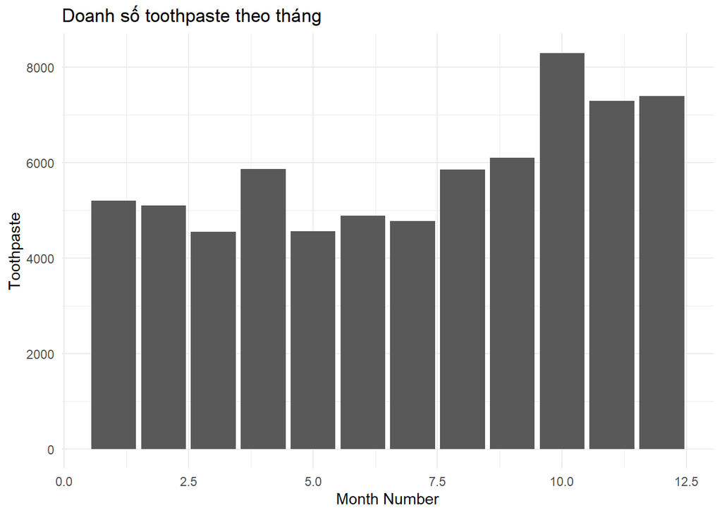

```r
ggplot(company_sales, aes(x=month_number, y=toothpaste))+
  geom_col()+
  labs(
    title="Doanh số toothpaste theo tháng",
    x="Month Number",
    y="Toothpaste")+
  theme_minimal()
```

## Q5

### Biểu đồ histogram của tổng lợi nhuận

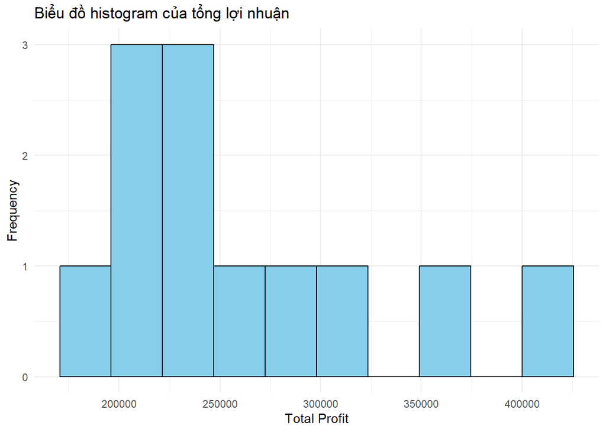

```r
ggplot(company_sales, aes(x = total_profit)) +
  geom_histogram(
    bins = 10,
    fill = "skyblue",
    color = "black"
  ) +
  labs(
    title = "Biểu đồ histogram của tổng lợi nhuận",
    x = "Total Profit",
    y = "Frequency"
  ) +
  theme_minimal()
```

*Phân tích*

- Biểu đồ histogram thể hiện phân bố của tổng lợi nhuận.
- Phần lớn giá trị lợi nhuận tập trung trong khoảng 200.000 đến 260.000.
- Một số giá trị lợi nhuận cao xuất hiện ở khoảng trên 350.000.
- Dữ liệu có sự phân bố không đồng đều và hơi lệch về phía giá trị lớn.
- Một số thời điểm có lợi nhuận tăng mạnh làm xuất hiện giá trị cao bất thường.

## Q6

### Biểu đồ phân tán để kiểm tra mối quan hệ giữa tổng số sản phẩm bán ra và tổng lợi nhuận

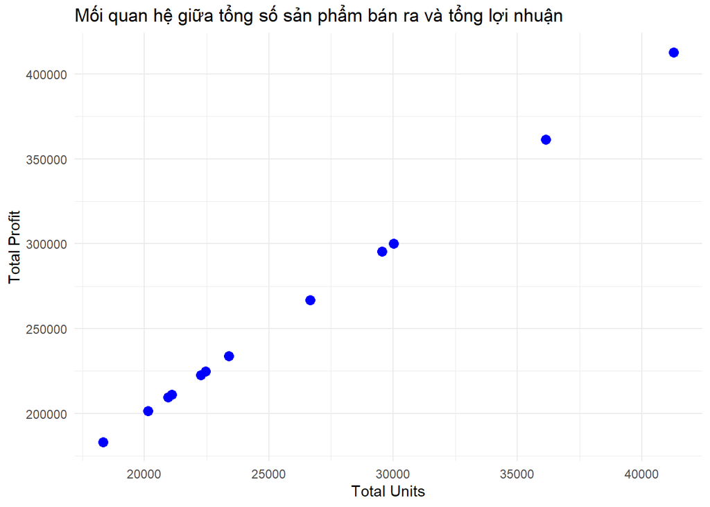

```r
ggplot(company_sales,
       aes(x = total_units,
           y = total_profit)) +
  geom_point(color = "blue", size = 3) +
  labs(
    title = "Mối quan hệ giữa tổng số sản phẩm bán ra và tổng lợi nhuận",
    x = "Total Units",
    y = "Total Profit"
  ) +
  theme_minimal()
```

*Phân tích*

- Biểu đồ scatter plot thể hiện mối quan hệ giữa tổng số sản phẩm bán ra và tổng lợi nhuận.
- Khi số lượng sản phẩm bán ra tăng thì tổng lợi nhuận cũng tăng.
- Các điểm dữ liệu có xu hướng đi lên từ trái sang phải.Điều này cho thấy hai biến có mối quan hệ thuận với nhau.

## Q7

### Biểu đồ đường so sánh doanh số của tất cả sản phẩm

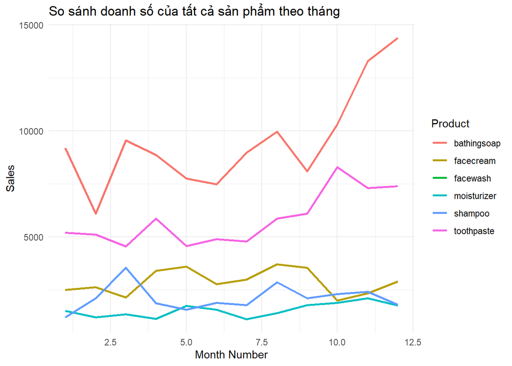

```r
company_sales_long <- company_sales %>%
  pivot_longer(
    cols = c(facecream, facewash, toothpaste,
             bathingsoap, shampoo, moisturizer),
    names_to = "Product",
    values_to = "Sales"
  )

ggplot(company_sales_long,
       aes(x = month_number,
           y = Sales,
           color = Product)) +
  geom_line(linewidth = 1) +
  labs(
    title = "So sánh doanh số của tất cả sản phẩm theo tháng",
    x = "Month Number",
    y = "Sales",
    color = "Product"
  ) +
  theme_minimal()
```

*So sánh doanh số của tất cả sản phẩm theo tháng*

- Biểu đồ thể hiện doanh số của tất cả sản phẩm theo từng tháng.
- Bathingsoap có doanh số cao nhất trong hầu hết các tháng.
- Facewash và moisturizer có doanh số thấp và khá ổn định.
- Nhiều sản phẩm có xu hướng tăng doanh số vào cuối năm.

## Q8

### Tổng số lượng bán ra trong cả năm cho từng sản phẩm

```r
product_sales <- company_sales %>%
  summarise(
    facecream = sum(facecream),
    facewash = sum(facewash),
    toothpaste = sum(toothpaste),
    bathingsoap = sum(bathingsoap),
    shampoo = sum(shampoo),
    moisturizer = sum(moisturizer)
  ) %>%
  pivot_longer(
    cols = everything(),
    names_to = "Product",
    values_to = "Total_Sales"
  )
```

### Vẽ biểu đồ cột

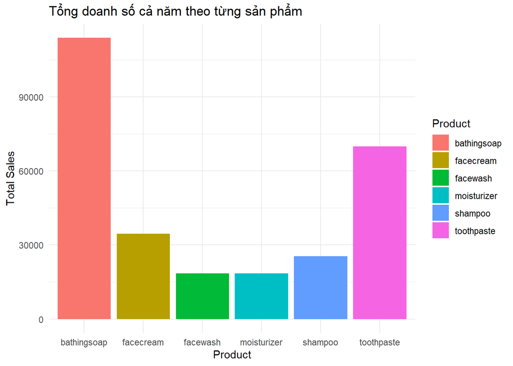

```r
ggplot(product_sales,
       aes(x = Product,
           y = Total_Sales,
           fill = Product)) +
  geom_col() +
  labs(
    title = "Tổng doanh số cả năm theo từng sản phẩm",
    x = "Product",
    y = "Total Sales"
  ) +
  theme_minimal()
```

*Phân tích*

- Biểu đồ cột thể hiện tổng doanh số cả năm của từng sản phẩm.
- Bathingsoap có tổng doanh số cao nhất.
- Toothpaste đứng thứ hai về doanh số.
- Facewash và moisturizer có tổng doanh số thấp nhất.

## Q9

### Vẽ boxplot cho doanh số của từng sản phẩm

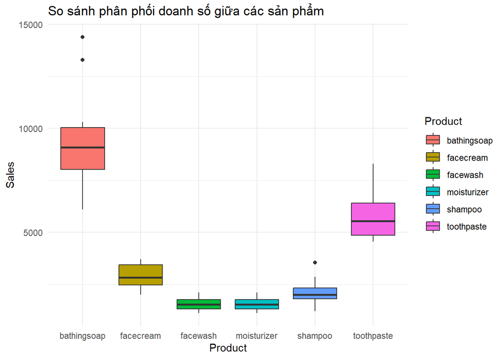

```r
ggplot(company_sales_long,
       aes(x = Product,
           y = Sales,
           fill = Product)) +
  geom_boxplot() +
  labs(
    title = "So sánh phân phối doanh số giữa các sản phẩm",
    x = "Product",
    y = "Sales"
  ) +
  theme_minimal()
```

*Phân tích*

- Biểu đồ boxplot thể hiện sự phân bố doanh số giữa các sản phẩm.
- Bathingsoap có doanh số cao nhất và độ biến động lớn.
- Facewash và moisturizer có doanh số thấp và khá ổn định.
- Toothpaste có doanh số tương đối cao so với các sản phẩm còn lại.
- Một số sản phẩm xuất hiện giá trị bất thường do doanh số tăng mạnh ở vài thời điểm: bathingsoap, shampoo

## Q10

### Biểu đồ thể hiện tỷ trọng doanh số từng sản phẩm trong cả năm

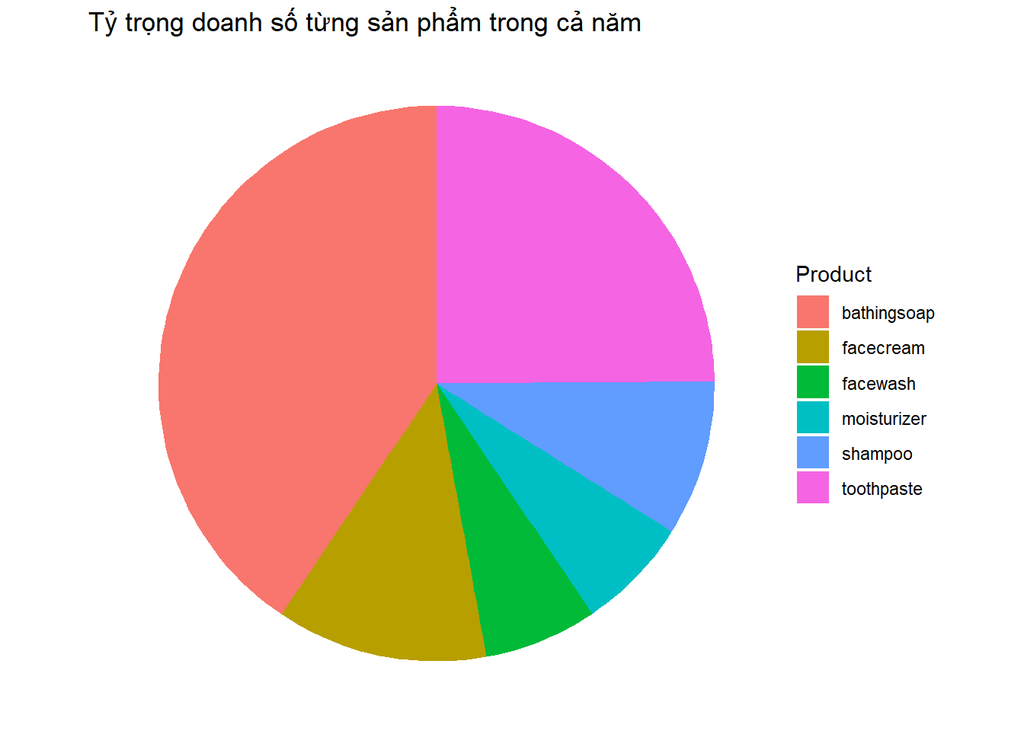

```r
product_sales <- product_sales %>%
  mutate(
    Percentage = Total_Sales / sum(Total_Sales) * 100
  )

ggplot(product_sales,
       aes(x = "",
           y = Percentage,
           fill = Product)) +
  geom_col(width = 1) +
  coord_polar(theta = "y") +
  labs(
    title = "Tỷ trọng doanh số từng sản phẩm trong cả năm",
    fill = "Product"
  ) +
  theme_void()
```

*Phân tích*

- Biểu đồ tròn thể hiện tỷ trọng doanh số của từng sản phẩm trong cả năm.
- Bathingsoap chiếm tỷ trọng lớn nhất.
- Toothpaste đứng thứ hai về tỷ trọng doanh số.
- Facewash và moisturizer chiếm tỷ trọng nhỏ nhất.